# IE582 PROJECT REPORT

#### Ahmet Karaköse - 2022402309

#### Eylül Güllü - 2021402255

#### Simay İkra Ergül - 2021402261

## 1. INTRODUCTION

### 1.1 Problem Description

The aim of this project is to develop a live betting strategy in soccer matches, which can predict the match outcome-home win, draw, or away win-and identify the single best time during a game at which to place a bet. Unlike most of the conventional prediction tasks, this problem has a lot of real-world constraints, since the decisions are allowed only once per match and must be based exclusively on data available up to that moment. Second, it does not use future data such as statistics and odds after the decision time to ensure the actuality and fairness of the prediction. The given dataset contains rich information, for example, real-time odds, match statistics, and game-changing events like goals and red cards; such an environment offers dynamism in intricacy. In particular, the competition requires balancing between predictive accuracy and profitability by using matches before November 1, 2024, for model development and those afterward for final testing.

The appropriate live betting strategy in soccer will have to thread a needle through many linked challenges if it is to achieve any degree of effectiveness. However, dynamic and volatile in-game odds are made of things that require models capable of extracting meaningful patterns from noise and yet capable of sudden shifts triggered by goals, red cards, or tactical changes. Determining a single best betting time calls for a tricky trade-off between prediction confidence and market profitability where an occasional error made in efforts of being highly accurate would translate to actual losses. This is further complicated by the temporal constraints of the task: Decisions must generalize to future, unseen matches with no iterative updates or access to future knowledge. The second objective-maximizing returns-develops an innovative metric and modeling technique that can align profitability with prediction quality. Together, these challenges point to the intrinsic and delicate balance between statistical rigor, real-time adaptability, and practical decision-making that underlies a successful betting strategy.

### 1.2 Summary of The Proposed Approach

In the framework of live soccer betting, such challenges are difficult to handle, and therefore, a multistep modeling pipeline was developed which combined clustering, feature engineering, and meta-modeling. We decided to start by enriching the feature set by incorporating variables like past victory ratios for home and away teams that considerably improved our models in terms of capturing intricate match dynamics and accounting for historical performance trends.

We then clustered the matches based on the odds distribution into three categories: balanced teams (Cluster 0), moderately imbalanced teams (Cluster 1), and clear favorites (Cluster 2). This clustering process allowed us to tailor our models to distinct types of matches, improving the prediction accuracy for each case. We evaluate the performance of four machine learning models, namely Decision Tree, Random Forest, SVM, and XGBoost, on each cluster by training and validating them on different time points in minutes to capture the dynamic nature of the game. The time frame of 10 to 45 minutes was selected for betting decisions because it provided the most stable data for accurate predictions, avoiding the noise of the first and second halves.

After identifying the best minutes and models, we tuned hyperparameters to further improve model performance. Other than improving robustness, we employed a meta-modeling approach to prevent overfitting in smaller clusters. This included using the output of base models as input to a meta-model, improving both model stability and profitability by capturing the strengths of each base model in a complementary way.

The general idea of our approach is that state-of-the-art feature engineering, strategically selected clustering, and meta-modeling produce an adaptive and accurate framework for live soccer betting. This layered approach balances effectively the prediction accuracy with profitability so that the models remain robust in the ever-changing environment of real-time sports betting.

### 1.3 Descriptive Analysis of Given Data

The dataset analyzed herein contains 648 unique matches with various features and statistics that were recorded at different time points. This data involves different aspects of the matches: the start and end times, the performance metrics of the teams, the odds, goal information, and card details, among other measures that will be useful in a deep analysis or comparison across games. It includes rich features of the performance of both home and away teams throughout the match, such as attack and defense statistics, shot attempts, possession percentages, and foul counts. The dataset gives a wide view of not only the outcomes of matches but also of the dynamics in each game and allows one to draw conclusions about factors that determine performance and can be used for betting predictions.

#### 1.3.1 Data columns segmentation:

1. Match Information: fixture_id, halftime, current_time, half_start_datetime, match_start_datetime, minute, second, latest_bookmaker_update, suspended, stopped, current_state, final_score, ticking, result.
2. Betting Information: 1, 2, X, name.
3. Match Statistics: Accurate Crosses, Assists, Attacks, Ball Possession %, Challenges, Corners, Counter Attacks, Dangerous Attacks, Dribble Attempts, Fouls, Free Kicks, Goal Attempts, Goal Kicks, Goals, Headers, Hit Woodwork, Injuries, Interceptions, Key Passes, Long Passes, Offsides, Passes, Penalties, Redcards, Saves, Score Change, Shots Blocked, Shots Insidebox, Shots Off Target, Shots On Target, Shots Outsidebox, Shots Total, Substitutions, Successful Dribbles, Successful Headers, Successful Interceptions, Successful Passes, Successful Passes Percentage, Tackles, Throwins, Total Crosses, Yellowcards, Yellowred Cards (all split into home and away).
4. Card Information: Yellowcards, Redcards, Yellowred Cards (for both home and away).
5. Score Information: Goals, Score Change (split into home and away), final_score, result.

#### 1.3.2 Match results distribution:

```
Total Matches: 648
```

1. Home Wins: 284 (43.83%)
2. Away Wins: 196 (30.25%)
3. Draws: 168 (25.93%)

#### 1.3.3 Missing values analysis

```
Total columns with missing values: 85
```

1. Free Kicks - away & Free Kicks - home (91.43%)
2. Injuries - away & Injuries - home (72.44%)
3. Counter Attacks - away & Counter Attacks - home (64.45%)
4. Assists - away & Assists - home (43.69%)
5. Goal Attempts - away & Goal Attempts - home (43.06%)

## 2. RELATED LITERATURE

### 2.1 Meta Models - Staking

```
A Novel Approach of Ensemble Methods Using the Stacked Generalization for High-dimensional Datasets (2022)
Authors: Suvita Rani Sharma, Birmohan Singh, Manpreet Kaur
```

The paper discusses how ensemble methods apply the method of stacked generalization, where multiple classifiers are combined to give one improved performance. The paper insists on the choice of proper classifiers for the first level, L0, of the stack. Similarly, in our project, we applied stacking in which we combined decision trees, random forests, XGBoost, and SVM models, having logistic regression as the meta-model. This is in line with the results of the paper, where the use of simple classifiers combined with ensemble techniques outperformed homogeneous ensemble classifiers to improve accuracy in predictions.

By investigating the stacking strategies on high-dimensional datasets, the paper proffers that the right choices of classifiers on the first level can boost the performance significantly. This is applicable to our work, where the models were chosen with care to complement each other using temporal clustering. We followed a similar approach since we tried to enhance the predictions by stacking, considering the performance of each model for different minutes of the match that helped us to optimize the accuracy and profitability of the dynamic betting model.

### 2.2 Machine Learning in Sports Betting

```
A Systematic Review of Machine Learning in Sports Betting: Techniques, Challenges, and Future Directions (2024)
Authors: René Manassé Galekwa, Jean Marie Tshimula, Etienne Gael Tajeuna, Kyandoghere Kyamakya
```

In our project, we will try to enhance sports betting predictions with the help of ML, considering how this area has already been influenced by the changes brought by ML. In recent research, it was specified that various ML techniques, such as support vector machines, random forests, and neural networks, are being used in the betting industry for better prediction, setting of odds, and handling of risks. These models use historical and real-time data in order to identify value bets and make wiser decisions on the part of bookmakers and bettors alike. While bookmakers will use ML to dynamically set odds and manage risk, for instance, the bettor exploits the insights for maximum profitability.

We also use similar machine learning techniques, such as Decision Trees and XGBoost, in our project, in tune with the industrial usage of tree-based methods. Feature engineering and model stacking will let us adapt to the ever-changing dynamics within sports events and make better betting decisions. The application of ML in our project closely resembles how it is actually applied in the industry: using historical data and in-game statistics to make better predictions and handle uncertainties with much more efficiency. In addition, anomaly detection models applied in the industry for fraud detection also examine the outcome of the match for our model's historical performance, with a view to limiting prediction risks by finding the proper trends.

## 3. APPROACH

### 3.1 Data Cleaning & Preparation

In this approach, we took several steps to clean and process the data for better prediction modeling:

1. Data Cleaning: We excluded suspended and stopped matches as they don’t reflect the typical match flow, which is essential for making accurate predictions.
2. Time Adjustments: The "halftime" column, in the raw dataset, had a marked beginning of every half, setting minute 0. We standardized those, changing the "current time" of the second half to be right after the end of the first one. We also dropped extra time since it is very unstable and unpredictable. Focusing just on the regular 90 minutes allowed us to rely on more meaningful and stable data for betting analytics.
3. Probability Columns: Using the odds from the betting data, we calculated the implied probabilities for each outcome (home, away, draw) to provide better context for predictions.
4. Encoding Target Column: We encoded the target "result" column with a LabelEncoder to map the outcomes into numeric values (Home = 0, Away = 1, Draw = 2).
5. Handling Missing Data: We filled missing data with zeros to avoid any issues when training the models, ensuring the dataset remained complete for all records.
6. Train & Test Set Seperation: We divided the data set into train and test sets based on the given date "2024-11-01".

### 3.2 Feature Engineering

This approach considers the computation of win ratios in a historical manner, which for any given current home and away team would take all previously played matches, excluding results of the match to which that ratio corresponds. After calculating in this manner, it tries to develop new features expressing past trends from teams which might help with predictive modeling or analytics using another technique. For computing the win ratios, separate calculations are performed for each team, only taking into consideration the matches they played as the home or away team according to the particular feature (home_win_ratio and away_win_ratio, respectively). By doing so, this allows these ratios to remain context-sensitive, reflecting exactly the teams' performance under question in regard to their roles.

Feature engineering here is necessary in this regard because it makes raw data from the matches meaningful for the understanding of underlying patterns. That means, by integrating the historical win ratio, we gave this model further insight into each team's performance dynamics in respect to the distribution of how well they did historically in those respective contexts-like home versus away. This then aids in developing a more complete predictive model while controlling for trending across each team and makes an informed model by previous exhibited performances of teams.

### 3.3 Match Clustering

The clustering process in this approach is aimed at categorizing matches based on the differences in the initial probabilities for the home and away teams (probabilities of home win and away win). By clustering the matches, we were able to classify them into three groups:

1. Cluster 0: Matches where the teams are of close strength, meaning the probability difference between the two teams is minimal (≤ 0.1). These are typically more unpredictable matches.
2. Cluster 1: Matches where the teams have moderate differences in their probabilities (0.1 < prob_diff ≤ 0.4). These are somewhat imbalanced, but not extreme.
3. Cluster 2: Matches where there is a clear favorite, with a large probability difference (≥ 0.4). These matches tend to have more predictable outcomes.

The reasoning behind this clustering is to help segment the data in a way that allows the model to treat each type of match differently. By doing so, we can apply tailored prediction strategies for each group. For instance, for Cluster 2 matches, we might prioritize the stronger team's performance, while for Cluster 0 matches, a more balanced prediction approach would be beneficial.

Cluster 0: 20 matches

Cluster 1: 56 matches

Cluster 2: 35 matches

### 3.4 Feature Selection

The following are the features that have been selected and considered relevant to capture the team performance during a match and historical trends that may affect the result of a match: goals, assists, shots on target, penalties. They indicate the direct dynamics of a match and may always affect its result. Moreover, the betting odds are given by Prob_1, Prob_2, Prob_X, reflecting the bookmaker's assessment of the chances of each team and thus providing a relevant external perspective. Similarly, **home_win_ratio** and **away_win_ratio** capture the historical performance of teams, which we have identified as one of the most relevant predictors from our earlier analyses. This combination of real-time match data and historical form makes our model comprehensive, capturing various factors influencing match results. Features which were informed by insight from our second homework showed their impact on model performance.

Selected Features: ["Assists - away", "Assists - home", "Attacks - away", "Attacks - home", "Ball Possession % - away", "Ball Possession % - home", "Challenges - away", "Challenges - home", "Goal Attempts - away", "Goal Attempts - home", "Goals - away", "Goals - home", "Penalties - away", "Penalties - home", "Redcards - away", "Redcards - home", "Saves - away", "Saves - home", "Shots On Target - away", "Shots On Target - home", 'Prob_1', 'Prob_2', 'Prob_X', 'home_win_ratio','away_win_ratio']

### 3.5 Initial Model Selection

These are the Decision Tree, Random Forest, Support Vector Machine (SVM), and XGBoost-forty models, which have been selected based on the diversity of powers, flexibility, and suitability, how things might go complex for them. Here's why every model was chosen:

1. Decision Tree: The model is simple, interpretable, and quite effective for classification problems. It can work on both categorical and numerical data, which best suits our task of predicting the outcomes of a match. It is easy to capture nonlinear relationships with decision trees, though controlling overfitting may require proper tuning. Interpretability becomes a key advantage when explaining model decisions, especially on complex data like match statistics.
2. Random Forest: This is an ensemble method built using Decision Trees. This improves the performance and generalizes because it averages over many trees, which reduces the problem of overfitting. It typically does very well for noisy data, or when it is hard for any one model to capture interactions among features very well. In our problem, Random Forest gives robust predictions through aggregating the insights of many Decision Trees trained on random subsets of the data.
3. Support Vector Machine: SVMs are well suitable to data of high dimensionalities. They work satisfactorily even in the case of linear or non-linear decision boundaries. They have acquired a reputation of good generalizing ability, more so when classes' decision boundaries are not easy to decide on. In prediction of the result of matches, SVM class distinction is quite feasible in complex data sets where intricacy of the patterns would happen.
4. XGBoost: This is a gradient boosting model, which has recently gained popularity due to its speed, efficiency, and performance of the model on machine learning tasks. It builds an ensemble of decision trees one after another. Each new tree added optimizes the model further. For structured data like ours, it handles missing values and unstructured data quite well, and many times, it outperforms other algorithms in predictive accuracy.

### 3.6 Model & Minute Determination for Clusters

We narrow down our range of interest to the 10th to 45th minute to find the best timing for making the betting decisions. The first 10 minutes are too volatile, and there is too little data to provide stable predictions. This is because the teams are just adjusting and finding their footing in the match; hence, the early dynamics of the match are harder to predict. By the second half, the market is much more reactive to the developments of the ongoing game, and the odds become less interpretable as teams reach the end of the match, often with quite varying levels of urgency and focus.

We ran four different models-Decision Tree, Random Forest, Support Vector Machine (SVM), and XGBoost-for every minute in the 10 to 45-minute window for each cluster. By comparing each model's result, we focused on minutes that have shown high profitability and strong prediction performance in most of them. To refine our minute selection and model, first, we extracted the top 10 highest-profit results across all models in each cluster. From this list we focused on two key aspects:

1. Model Frequency: We have noticed which models keep popping into the top 10 profit list. More weight has been given to the models that perform well in a selection process with consistency.
2. Minute Consistency: We computed minutes or minutes around those minutes performing well across many different models. In the case when a minute is performing well on many models, that can indicate that a minute would give valuable insight irrespective of what model is applied to the data.

By combining these two criteria—frequent models and consistent minutes—we selected the a well performing model-minute combinations for each cluster. This methodology ensured that our final selection was robust, taking advantage of both the models' strength and the temporal consistency of certain match moments, which ultimately enhanced our betting strategy's accuracy and profitability.

### 3.7 Hyperparameter Tuning & Application on Test Set

After selecting the best model for each cluster by choosing the best minute, we perform further fine-tuning of this selected model. This is important to be carried out in order to optimize its performance so as to generalize much better on unseen test data and increase the predictive accuracy of the model.

Using the optimized hyperparameters, we evaluated the last model setup on the freely available test data. There were two metric criteria upon which the results were judged: profitability and accuracy. Profitability was assessed by estimating how effective the model was able to formulate potential betting suggestions, while accuracy measured the efficacy of the model in predicting outcomes of the matches.

### 3.8 Meta Model Process

Stacking, or stacked generalization, is an ensembling technique wherein more than one base model is independently trained and used in the training of a higher-order model, generally known as the meta-model. These might include, for example, Decision Trees, Random Forests, Support Vector Machines, and XGBoost-all different kinds of classifiers-whose outputs can then be fed as input into another model, which finally predicts. This can lead to better predictions by exploiting a set of models and, furthermore, reduces overfitting or biased predictions from a single model.

We adopt this stacking mainly to enhance the performance both for every cluster and independently for each minute, ranging from 10 to 45. First of all, we evaluate the base models, then apply stacking to combine these model predictions in a more robust way. This arises because the use of stacking reduces the variance in the predictions that may arise with a single model and hence can yield more accuracy and profitability. It is expected that the meta-model learns the optimal combination of the predictions made by the base models with the help of Logistic Regression to obtain more reliable results.

## 4. RESULTS

### 4.1 Before Meta Modelling

#### 4.1.1 Cluster 0

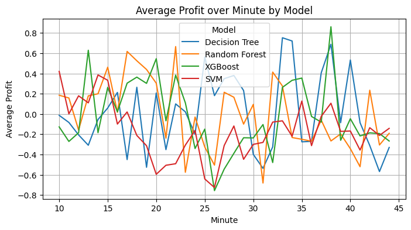

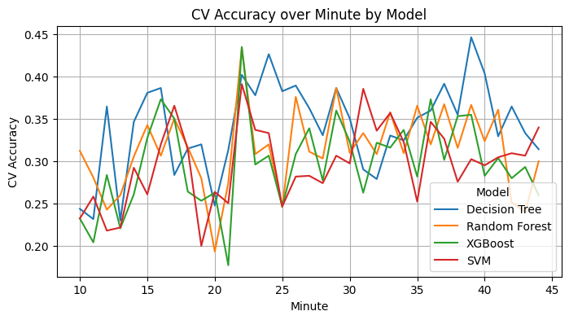

|  | Cluster | Minute | Model | Average Profit | CV_Accuracy |
| --- | --- | --- | --- | --- | --- |
| 114 | 0 | 38 | XGBoost | 0.861000 | 0.353333 |
| 92 | 0 | 33 | Decision Tree | 0.752500 | 0.330476 |
| 96 | 0 | 34 | Decision Tree | 0.720500 | 0.324762 |
| 112 | 0 | 38 | Decision Tree | 0.688000 | 0.355000 |
| 49 | 0 | 22 | Random Forest | 0.665263 | 0.434066 |
| 14 | 0 | 13 | XGBoost | 0.629000 | 0.220833 |
| 29 | 0 | 17 | Random Forest | 0.617368 | 0.350476 |
| 60 | 0 | 25 | Decision Tree | 0.562941 | 0.382857 |
| 42 | 0 | 20 | XGBoost | 0.545556 | 0.262857 |
| 120 | 0 | 40 | Decision Tree | 0.532632 | 0.403810 |

Before applying the model to the test data, we performed hyperparameter tuning for the Decision Tree model and used the best parameters obtained.

The results for Cluster 0 at the 34th minute are as follows:

|  | Total Profit | Average Profit per Bet | Accuracy | Total Bets |
| --- | --- | --- | --- | --- |
| 0 | 1.09 | 0.060556 | 0.333333 | 18 |

Here, we notice that the accuracy is somewhat low. However, considering that the match involves two closely matched teams, this result can be considered reasonable. Despite this, we achieved a positive return.

#### 4.1.2 Cluster 1

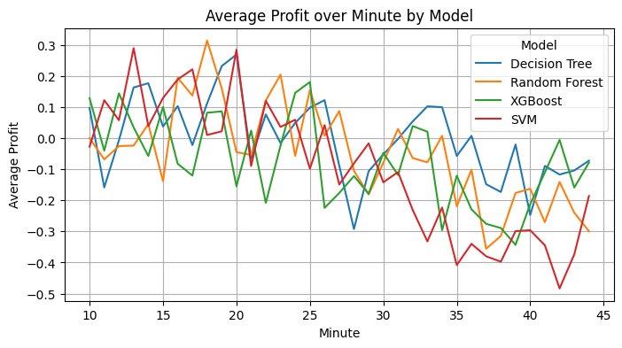

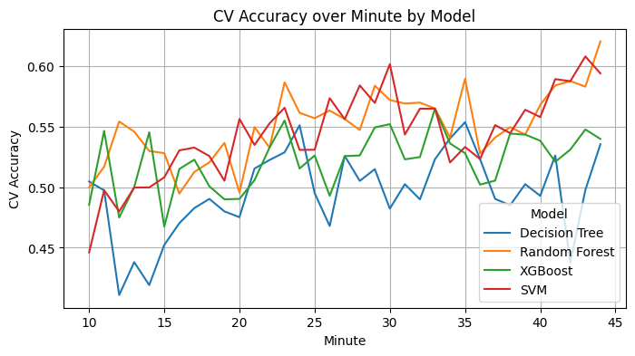

|  | Cluster | Minute | Model | Average Profit | CV_Accuracy |
| --- | --- | --- | --- | --- | --- |
| 173 | 1 | 18 | Random Forest | 0.314655 | 0.520641 |
| 155 | 1 | 13 | SVM | 0.290000 | 0.499730 |
| 183 | 1 | 20 | SVM | 0.284909 | 0.556538 |
| 180 | 1 | 20 | Decision Tree | 0.269273 | 0.475256 |
| 176 | 1 | 19 | Decision Tree | 0.232321 | 0.480027 |
| 171 | 1 | 17 | SVM | 0.221786 | 0.532821 |
| 193 | 1 | 23 | Random Forest | 0.204576 | 0.586775 |
| 165 | 1 | 16 | Random Forest | 0.194483 | 0.494744 |
| 167 | 1 | 16 | SVM | 0.189310 | 0.530513 |
| 202 | 1 | 25 | XGBoost | 0.180862 | 0.526316 |

Before applying the model to the test data, we performed hyperparameter tuning for the SVM model and utilized the optimal parameters obtained.

The results for Cluster 1 at the 20th minute are as follows:

|  | Total Profit | Average Profit per Bet | Accuracy | Total Bets |
| --- | --- | --- | --- | --- |
| 0 | 0.15 | 0.00283 | 0.490566 | 53 |

When analyzing the results, we can see that the **Accuracy** has improved compared to Cluster 0; however, the **Total Profit** is lower than that of Cluster 0.

#### 4.1.3 Cluster 2

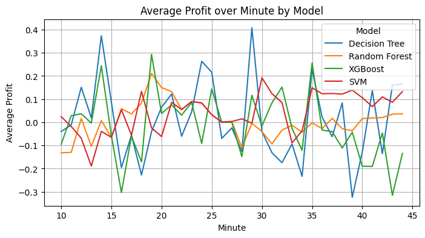

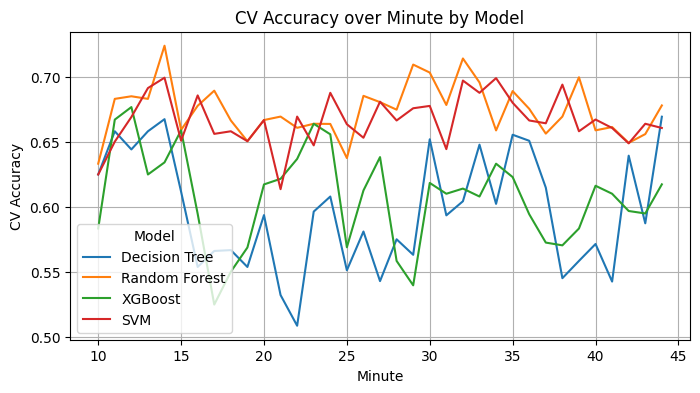

|  | Cluster | Minute | Model | Average Profit | CV_Accuracy |
| --- | --- | --- | --- | --- | --- |
| 356 | 2 | 29 | Decision Tree | 0.408387 | 0.563043 |
| 296 | 2 | 14 | Decision Tree | 0.373548 | 0.667667 |
| 318 | 2 | 19 | XGBoost | 0.293125 | 0.568667 |
| 336 | 2 | 24 | Decision Tree | 0.263437 | 0.608000 |
| 382 | 2 | 35 | XGBoost | 0.256250 | 0.623000 |
| 298 | 2 | 14 | XGBoost | 0.244194 | 0.634333 |
| 380 | 2 | 35 | Decision Tree | 0.229063 | 0.655667 |
| 340 | 2 | 25 | Decision Tree | 0.216061 | 0.551087 |
| 317 | 2 | 19 | Random Forest | 0.210938 | 0.650667 |
| 363 | 2 | 30 | SVM | 0.192143 | 0.677899 |

Before applying the model to the test data, we performed hyperparameter tuning for the Decision Tree model and utilized the optimal parameters obtained.

The results for Cluster 2 at the 14th minute are as follows:

|  | Total Profit | Average Profit per Bet | Accuracy | Total Bets |
| --- | --- | --- | --- | --- |
| 0 | 0.75 | 0.024194 | 0.645161 | 31 |

Our **Accuracy** is higher compared to **Cluster 0** and **Cluster 1**, likely due to the nature of these matches, where one team is more favored. However, our **Total Profit** is not at an ideal level. This could be attributed to the lower returns from odds when we correctly predict a match outcome.

#### 4.1.4 Overall Results

|  | Metric | Value |
| --- | --- | --- |
| 0 | Total Profit | 1.990000 |
| 1 | Total Bets | 102.000000 |
| 2 | Overall Accuracy | 0.509804 |

In conclusion, our accuracy is slightly above 50%, but the total profit remains significantly low.

### 4.2 Meta Modelling Results

First, Cluster 0, Cluster 1, and Cluster 2 were analyzed separately using four different machine learning models-Decision Tree, Random Forest, SVM, and XGBoost-on selected time slots. These models needed to be ranked based on metrics like average profit and accuracy. In finding a balance between accuracy and profitability, huge variance issues were seen in certain time slots.

This showed a significant amount of deviation for the same time slot amongst models, thus making a decision cumbersome. Each model was found to do well in certain situations and failed in others; hence, no model was found to generalize very well. Finally, the search for a more balanced solution gave way to find that the problems related to variance could be resolved with the use of meta-model approaches like stacking. The meta-model is using the output of four base models: Decision Tree, Random Forest, SVM, and XGBoost. It uses a higher-level model, Logistic Regression, to predict.

The use of the meta-model brought the following advantages: reducing variance by combining the strengths of different models, compensating for the weaknesses of base models in certain scenarios using the outputs of other models, achieving a more balanced accuracy and profitability ratio. Thus, the adoption of the meta-model significantly improved the stability and generalization capacity of the results, minimizing variance-related problems.

### 4.2.1 Cluster 0

On the test set for Cluster 0, the base model returned a total profit of 1.09 units, 0.06 units of profit per bet, and with an accuracy of 33.33%. Meanwhile, for the meta-model, the results were as follows: for a total profit of 6.92 units, the average profit per bet of 0.36 units is the accuracy of 47.37%. Therefore, the ability to select time slots by this meta-model proved positive. Concretely, the 27th minute was chosen because in the higher slots of average profit the accuracy was not as high. The application of the meta-model allowed us to get an improvement in the accuracy and profit obtained. In Cluster 0, the close probabilities of home and away team wins, besides fewer matches when compared to the other clusters, could result in less reliability from the results given by a single model.

|  | Cluster | Minute | Model | Average Profit | CV_Accuracy |
| --- | --- | --- | --- | --- | --- |
| 11 | 0 | 21 | Stacking | 0.848947 | 0.326667 |
| 26 | 0 | 36 | Stacking | 0.656000 | 0.373333 |
| 28 | 0 | 38 | Stacking | 0.586500 | 0.236667 |
| 15 | 0 | 25 | Stacking | 0.575294 | 0.206667 |
| 8 | 0 | 18 | Stacking | 0.518947 | 0.356667 |
| 17 | 0 | 27 | Stacking | 0.484444 | 0.417143 |
| 16 | 0 | 26 | Stacking | 0.375556 | 0.308571 |
| 24 | 0 | 34 | Stacking | 0.258000 | 0.392381 |
| 33 | 0 | 43 | Stacking | 0.199500 | 0.360000 |
| 34 | 0 | 44 | Stacking | 0.173158 | 0.464762 |

|  | Total Profit | Average Profit per Bet | Accuracy | Total Bets |
| --- | --- | --- | --- | --- |
| 0 | 6.92 | 0.364211 | 0.473684 | 19 |

### 4.2.2 Cluster 1

On Cluster 1, the base model returned an overall profit of 0.15 units with a mean of 0.0028 units of profit per bet at an accuracy of 49.06%. The meta-model chose the 19th minute because this minute had the best average profit at good enough accuracy. The meta-model results had an increased overall profit of 2.12 units, the average profit increased to 0.04 units per bet at an accuracy of 48.08%. While the accuracy for Cluster 1 remained almost the same, the average profit improved by a large margin.

|  | Cluster | Minute | Model | Average Profit | CV_Accuracy |
| --- | --- | --- | --- | --- | --- |
| 44 | 1 | 19 | Stacking | 0.236429 | 0.505533 |
| 48 | 1 | 23 | Stacking | 0.163390 | 0.549933 |
| 41 | 1 | 16 | Stacking | 0.127241 | 0.494872 |
| 50 | 1 | 25 | Stacking | 0.116552 | 0.546424 |
| 51 | 1 | 26 | Stacking | 0.108571 | 0.518333 |
| 56 | 1 | 31 | Stacking | 0.089483 | 0.502564 |
| 43 | 1 | 18 | Stacking | 0.075172 | 0.510513 |
| 35 | 1 | 10 | Stacking | 0.054194 | 0.499878 |
| 58 | 1 | 33 | Stacking | 0.049107 | 0.524157 |
| 46 | 1 | 21 | Stacking | 0.048727 | 0.530000 |

|  | Total Profit | Average Profit per Bet | Accuracy | Total Bets |
| --- | --- | --- | --- | --- |
| 0 | 2.12 | 0.040769 | 0.480769 | 52 |

### 4.2.3 Cluster 2

For Cluster 2, the base model returned a total profit of 0.75 units, an average profit per bet of 0.02 units, and an accuracy of 64.52%. The 15th minute was selected in the meta-model because it had the highest average profit with sufficient accuracy. With the meta-model, the overall profit came down to 0.58 units, while the average profit per bet remained the same at 0.02 units, with accuracy increasing to 73.53%. The increased accuracy for Cluster 2 provided more reliable results, but this can be seen as a drop in profitability due to the strategy used to enhance accuracy.

|  | Cluster | Minute | Model | Average Profit | CV_Accuracy |
| --- | --- | --- | --- | --- | --- |
| 75 | 2 | 15 | Stacking | 0.292000 | 0.643385 |
| 95 | 2 | 35 | Stacking | 0.229063 | 0.647667 |
| 78 | 2 | 18 | Stacking | 0.213226 | 0.633333 |
| 79 | 2 | 19 | Stacking | 0.187188 | 0.635000 |
| 81 | 2 | 21 | Stacking | 0.177097 | 0.637333 |
| 82 | 2 | 22 | Stacking | 0.168485 | 0.645333 |
| 103 | 2 | 43 | Stacking | 0.131935 | 0.638768 |
| 80 | 2 | 20 | Stacking | 0.128125 | 0.650667 |
| 74 | 2 | 14 | Stacking | 0.068710 | 0.707667 |
| 97 | 2 | 37 | Stacking | 0.016875 | 0.639493 |

|  | Total Profit | Average Profit per Bet | Accuracy | Total Bets |
| --- | --- | --- | --- | --- |
| 0 | 0.58 | 0.017059 | 0.735294 | 34 |

### 4.2.4 Overall Results

This in turn means a significant improvement in overall results from meta-models. While the meta-model resulted in total profits reaching 9.62 units compared with that of the base model, achieving only 1.99 units of profit, show what advantage the meta-model has over single or more models combined that generate higher profitability.

Regarding accuracy, the overall accuracy of the meta-model was 56.19%, compared to 50.98% for the base model, reflecting a meaningful improvement. This increase demonstrates the meta-model's ability to select the optimal time slots and reduce variance. The meta-model not only improved accuracy but also effectively balanced accuracy and profitability, enhancing overall performance.

|  | Metric | Value |
| --- | --- | --- |
| 0 | Total Profit | 9.620000 |
| 1 | Total Bets | 105.000000 |
| 2 | Overall Accuracy | 0.561905 |

## 5. CONCLUSIONS & FUTURE WORK

This work investigates the application of machine learning models to improve profitability in sports betting by predictive analytics on match outcomes. We have investigated both base and meta-model approaches and see significant improvements in profitability and accuracy. While the performance was not very different for individual models like Decision Trees and Support Vector Machines-the fact that some slots were positive meant that model variance was problematic-the performance of the meta-models showed a great improvement in performance, with a reduction of variance, selection of time slots, and a balance between profitability and accuracy combined in one by merging several base models using a logistic regression approach. The main conclusion from our results is that meta-modelling in itself has been pretty effective, especially because of the variability and uncertainty of sports events.

While the base models did a pretty good job, the meta-model outperformed them by a long way, improving profitability-the total profit was 9.62 units-and increasing overall accuracy to 56.19%. The stacking of different models together had some much better results, showing the true value of this technique in high-variance classification problems like sports betting. While the models are improved, there is still much work to be done regarding how to stay profitable without losing much accuracy, especially when dealing with more unpredictable events. In the future, the model can be improved by incorporating more sophisticated data features, such as quantification of player performances and in-depth scrutiny of betting odds. Further exploration of other ensemble learning methods and incorporating time-related factors may yield more subtly shaded predictions.

Other tests that could be further done relate to the scalability of the model across a wide variety of sports or betting markets, and adaptability in real-time betting environments. Besides these, from an ethical point of view, fairness and transparency of the prediction model have to be taken care of in order to increase the rate of acceptance and implementation of such systems within the betting industry.

## 6. CODE

https://github.com/BU-IE-582/fall-24-akarakose/blob/3a3a6c6332bdccc33e16a1e5dbece59f5674f4b3/IE582_project_final.ipynb